# Discriminant Analysis with Categorical Variable

# **4. 데이터 분할**

```r
# Partition (Training Dataset : Test Dataset = 7:3)
y      <- UB.df$Personal.Loan                            # Target

set.seed(200)
ind    <- createDataPartition(y, p = 0.7, list = T)      # Index를 이용하여 7:3으로 분할
UB.trd <- UB.df[ind$Resample1,]                          # Training Dataset
UB.ted <- UB.df[-ind$Resample1,]                         # Test Dataset
```

# **5. 데이터 전처리 II**

```r
# Standardization
preProcValues <- preProcess(UB.trd[,c(2:5, 9, 12)],         # Target과 Dummy 변수 제외
                            method = c("center", "scale"))  # Standardization 정의 -> Training Dataset에 대한 평균과 표준편차 계산

UB.trd <- predict(preProcValues, UB.trd)                    # Standardization for Training Dataset
UB.ted <- predict(preProcValues, UB.ted)                    # Standardization for Test Dataset

glimpse(UB.trd)                                             # 데이터 구조 확인
```

```
Rows: 1,751
Columns: 16
$ Personal.Loan        <fct> no, no, no, no, no, no, no, yes, no, no…
$ Age                  <dbl> -0.05431273, -0.57446728, -0.92123699, …
$ Experience           <dbl> -0.12175295, -0.46882565, -0.98943471, …
$ Income               <dbl> -0.85867297, -1.35649686, 0.56986515, -…
$ ZIP.Code             <dbl> -1.75250883, 0.88354520, 0.53745994, -1…
$ Family.2             <dbl> 0, 0, 0, 0, 1, 0, 0, 0, 0, 0, 1, 0, 0, …
$ Family.3             <dbl> 1, 0, 0, 0, 0, 0, 1, 0, 0, 1, 0, 0, 0, …
$ Family.4             <dbl> 0, 0, 0, 1, 0, 0, 0, 0, 1, 0, 0, 1, 0, …
$ CCAvg                <dbl> -0.25119120, -0.53150921, 0.42157204, -…
$ Education.2          <dbl> 0, 0, 1, 1, 1, 0, 1, 0, 0, 1, 0, 1, 0, …
$ Education.3          <dbl> 0, 0, 0, 0, 0, 1, 0, 1, 1, 0, 1, 0, 0, …
$ Mortgage             <dbl> -0.5664192, -0.5664192, -0.5664192, -0.…
$ Securities.Account.1 <dbl> 1, 0, 0, 0, 0, 0, 0, 0, 0, 0, 1, 0, 1, …
$ CD.Account.1         <dbl> 0, 0, 0, 0, 0, 0, 0, 0, 0, 0, 0, 0, 0, …
$ Online.1             <dbl> 0, 0, 0, 0, 1, 0, 1, 0, 0, 1, 0, 1, 0, …
$ CreditCard.1         <dbl> 0, 0, 0, 1, 0, 1, 0, 0, 0, 0, 0, 0, 0, …
```

```r
glimpse(UB.ted)                                             # 데이터 구조 확인
```

```
Rows: 749
Columns: 16
$ Personal.Loan        <fct> no, no, no, no, no, no, no, no, no, no,…
$ Age                  <dbl> -1.7881612, -0.7478521, 1.2460737, 0.81…
$ Experience           <dbl> -1.68358012, -0.64236200, 0.83269699, 0…
$ Income               <dbl> -0.53400522, -0.96689556, -1.11840718, …
$ ZIP.Code             <dbl> -1.17304370, -0.59585545, 1.07366441, 0…
$ Family.2             <dbl> 0, 0, 0, 0, 0, 0, 0, 0, 0, 0, 0, 0, 0, …
$ Family.3             <dbl> 0, 0, 0, 0, 0, 0, 0, 0, 1, 1, 0, 1, 0, …
$ Family.4             <dbl> 1, 1, 0, 0, 1, 0, 1, 1, 0, 0, 0, 0, 0, …
$ CCAvg                <dbl> -0.19512759, -0.86789083, -0.25119120, …
$ Education.2          <dbl> 0, 1, 0, 1, 1, 0, 0, 0, 0, 1, 0, 1, 0, …
$ Education.3          <dbl> 0, 0, 1, 0, 0, 1, 1, 1, 1, 0, 0, 0, 0, …
$ Mortgage             <dbl> -0.5664192, 0.9609885, -0.5664192, -0.5…
$ Securities.Account.1 <dbl> 1, 0, 0, 1, 0, 0, 0, 0, 1, 0, 0, 1, 1, …
$ CD.Account.1         <dbl> 0, 0, 0, 0, 0, 0, 0, 0, 0, 0, 0, 1, 0, …
$ Online.1             <dbl> 0, 1, 1, 0, 1, 1, 1, 1, 0, 1, 1, 1, 0, …
$ CreditCard.1         <dbl> 0, 0, 1, 1, 0, 1, 0, 0, 0, 0, 0, 0, 0, …
```

# **6. 모공분산행렬의 동일성 검정**

```r
UB.boxM <- boxM(UB.trd[,-1],                  # Dataset including Only 예측 변수 -> Target 제외
                UB.trd$Personal.Loan)         # Target
UB.boxM
```

```
    Box's M-test for Homogeneity of Covariance Matrices

data:  UB.trd[, -1]
Chi-Sq (approx.) = 980.59, df = 120, p-value < 2.2e-16
```

`Caution!` Package `"biotools"`에서 제공하는 함수 `boxM()`를 이용하여 모공분산행렬의 동일성 검정을 수행할 수 있다. 해당 검정에서 귀무가설 $H_0$은 “Target의 모든 클래스의 모공분산행렬은 동일하다.”이며, 귀무가설 $H_0$을 기각할 증거가 부족할 경우 원칙적으로는 선형판별분석을 수행한다.  
`Result!` 가설 $H_0 :\Sigma_{\text{yes}}=\Sigma_{\text{no}}$ vs $H_1 :\Sigma_{\text{yes}}\ne\Sigma_{\text{no}}$에 대하여, 카이제곱 검정통계량 $\chi^2$값은 980.59이며 $p$값은 거의 0값에 가깝다. 이에 근거하여, 유의수준 5%에서 $p$값이 0.05보다 작기 때문에 귀무가설 $H_0$를 기각할 수 있다. 즉, `Training Dataset`에서 Target “Personal.Loan”의 두 클래스 “no”와 “yes”의 모공분산행렬은 동일하지 않다.

# **7. 선형판별분석(LDA)**

## **7-1. 모형 훈련**

`Caution!` Package `"MASS"`에서 제공하는 함수 `lda()`를 통해 선형판별함수 $L(x)$를 얻을 수 있다. 함수 `lda()`는 예측 변수의 평균을 0으로 변환(중심화)한 후 분석을 수행하며, 정규화된 판별계수벡터 $\boldsymbol{b}$를 계산한다. 여기서, 정규화된 판별계수벡터란 합동공분산행렬을 $\boldsymbol{S}$라 할 때 $\boldsymbol{b}^T \boldsymbol{S}\boldsymbol{b}=1$을 만족하는 $\boldsymbol{b}$를 의미한다.

```r
UB.lda <- lda(Personal.Loan ~ .,
              # prior = c(1/2, 1/2),            # 사전확률
              data = UB.trd)
UB.lda
```

```
Call:
lda(Personal.Loan ~ ., data = UB.trd)

Prior probabilities of groups:
       no       yes
0.8972016 0.1027984

Group means:
             Age   Experience     Income     ZIP.Code  Family.2
no   0.007050718  0.006493842 -0.1773736 -0.001354389 0.2590707
yes -0.061537099 -0.056676814  1.5480771  0.011820808 0.1722222
     Family.3  Family.4      CCAvg Education.2 Education.3
no  0.1909612 0.2565245 -0.1247715   0.2647995   0.2781668
yes 0.2722222 0.3166667  1.0889781   0.3888889   0.4055556
       Mortgage Securities.Account.1 CD.Account.1  Online.1
no  -0.05226732            0.1094844   0.03437301 0.6034373
yes  0.45617752            0.1444444   0.32222222 0.6611111
    CreditCard.1
no     0.2934437
yes    0.2722222

Coefficients of linear discriminants:
                             LD1
Age                  -0.47464616
Experience            0.50676236
Income                1.00862440
ZIP.Code              0.04036519
Family.2             -0.02446717
Family.3              0.60520194
Family.4              0.54284147
CCAvg                 0.12422080
Education.2           0.97482668
Education.3           1.03737093
Mortgage              0.05091070
Securities.Account.1 -0.47479897
CD.Account.1          2.43620067
Online.1             -0.14846577
CreditCard.1         -0.40061099
```

`Caution!` “Prior probabilities of groups”는 Target의 각 클래스에 대한 사전확률을 의미하며, 함수 `lda()`의 옵션 `prior`을 이용하여 직접 지정할 수 있다. 옵션을 따로 지정해주지 않으면, `Training Dataset`에서 Target의 클래스 비율을 사전확률로 사용한다.  
“Group means”는 Target의 클래스별 예측 변수들의 평균을 의미한다.  
“Coefficients of linear discriminants”는 선형판별함수의 정규화된 판별계수벡터를 의미한다.  
`Result!` `Training Dataset` “UB.trd”에서 Target “Personal.Loan”의 클래스별 비율은 각각 “no” 89.7%, “yes” 10.3%이다. “Coefficients of linear discriminants”에 출력된 결과를 이용하여 선형판별함수 $L(x)$를 다음과 같이 얻을 수 있다.

$$\begin{align*}
L(x) = &-0.475Z_{\text{Age}} + 0.507 Z_{\text{Experience}} + 1.009 Z_{\text{Income}} + 0.040 Z_{\text{ZIP.Code}}\\
&-0.024 (X_{\text{Family.2}} - \bar{X}_{\text{Family.2}}) + 0.605 (X_{\text{Family.3}} - \bar{X}_{\text{Family.3}}) + 0.543 (X_{\text{Family.4}} - \bar{X}_{\text{Family.4}}) + 0.124 Z_{\text{CCAvg}} \\
&+ 0.975 (X_{\text{Education.2}} - \bar{X}_{\text{Education.2}}) + 1.037 (X_{\text{Education.3}} - \bar{X}_{\text{Education.3}}) + 0.051 Z_{\text{Mortgage}} \\
&-0.475 (X_{\text{Securities.Account.1}} - \bar{X}_{\text{Securities.Account.1}}) +2.436 (X_{\text{CD.Account.1}} - \bar{X}_{\text{CD.Account.1}}) \\
&-0.148 (X_{\text{Online.1}} - \bar{X}_{\text{Online.1}}) -0.401 (X_{\text{CreditCard.1}} - \bar{X}_{\text{CreditCard.1}})
\end{align*}$$
여기서, $Z_{\text{예측 변수}}$는 표준화한 예측 변수, $X_{\text{예측 변수}}$는 더미 변수를 의미한다. 예를 들어, $X_{\text{Family.2}}$는 가족 수가 2명인 경우 “1”값을 가지고 2명이 아니면 “0”값을 가진다. 위에서 언급했듯이 함수 `lda()`는 예측 변수의 평균을 0으로 변환한 후 분석을 수행하기 때문에 더미 변수들은 평균 $\bar{X}_{\text{예측 변수}}$ 항을 추가하였으며, 나머지 예측 변수들은 데이터 전처리 II에서 표준화를 수행하여 평균이 0이기 때문에 평균항을 추가하지 않았다.
판별계수의 부호를 이용하여 해석해보면, 판별계수가 양수인 예측 변수(예를 들어, “Experience”, “Income” 등)의 값이 클수록 선형판별함수 $L(x)$의 값이 커지며, 이는 개인 대출 제의를 수락할 가능성(Target “Personal.Loan = yes”일 확률)이 커진다는 것을 의미한다.

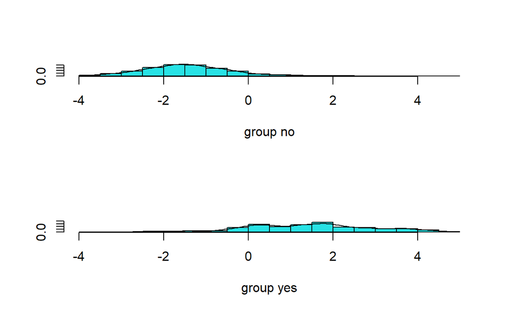

```r
# Target "Personal.Loan"의 클래스별 판별점수 히스토그램
plot(UB.lda, dimen = 1, type = "b")
```

`Result!` 각 case에 대하여 예측 변수들의 관측값을 위에서 구한 선형판별함수 $L(x)$에 대입하여 얻은 값을 “판별점수”라고 한다. `Training Dataset`의 Target “Personal.Loan”의 클래스별 판별점수 히스토그램을 살펴보면, “no”에 속하는 case의 판별점수는 대체로 0보다 작은 음수값이고 “yes”에 속하는 case의 판별점수는 대체로 0보다 큰 양수값이다.

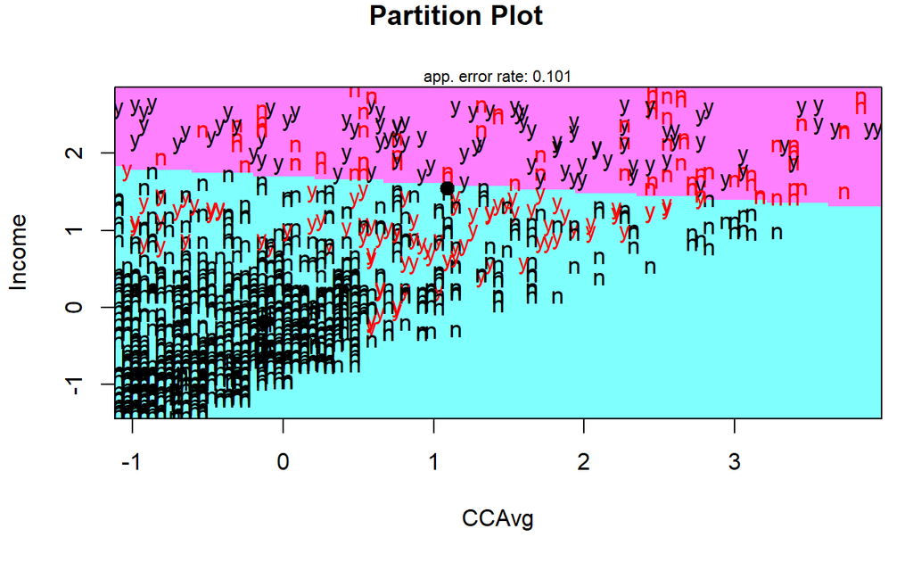

```r
# 두 예측 변수 "Income"와 "CCAvg"에 대해 선형판별분석에 기초한 관측값의 분류 결과
partimat(Personal.Loan ~ Income + CCAvg ,
         data = UB.trd,
         method = "lda")
```

`Result!` 빨간색은 잘못 분류된 case를 의미하며, 직선형태로 분류 영역이 나뉘어져 있다는 것을 알 수 있다.

## **7-2. 모형 평가**

`Caution!` 모형 평가를 위해 `Test Dataset`에 대한 `예측 class/확률`이 필요하며, 함수 `predict()`를 이용하여 생성한다.

```r
# 예측 class와 예측 확률 생성
UB.lda.pred <- predict(UB.lda,
                       newdata = UB.ted[,-1])           # Test Dataset including Only 예측 변수

UB.lda.pred %>%
  as_tibble
```

```
# A tibble: 749 × 3
   class posterior[,"no"]  [,"yes"] x[,"LD1"]
   <fct>            <dbl>     <dbl>     <dbl>
 1 no               1.00  0.0000810   -1.30
 2 no               0.999 0.00119     -0.384
 3 no               1.00  0.0000388   -1.55
 4 no               1.00  0.0000131   -1.92
 5 no               0.999 0.00112     -0.406
 6 no               1.00  0.000372    -0.782
 7 no               0.995 0.00488      0.0955
 8 no               0.953 0.0472       0.882
 9 no               0.976 0.0241       0.646
10 no               0.996 0.00405      0.0317
# ℹ 739 more rows
```

`Result!` 함수 `predict()`는 3개의 결과를 리스트로 반환한다.

1. `class` : 예측 class
2. `posterior` : 각 클래스에 대한 예측 확률(사후 확률)
3. `x` : 판별점수

### **7-2-1. ConfusionMatrix**

```r
CM   <- caret::confusionMatrix(UB.lda.pred$class, UB.ted$Personal.Loan,
                               positive = "yes")        # confusionMatrix(예측 class, 실제 class, positive = "관심 class")
CM
```

```
Confusion Matrix and Statistics

          Reference
Prediction  no yes
       no  659  26
       yes  14  50

               Accuracy : 0.9466
                 95% CI : (0.928, 0.9616)
    No Information Rate : 0.8985
    P-Value [Acc > NIR] : 1.605e-06

                  Kappa : 0.6851

 Mcnemar's Test P-Value : 0.08199

            Sensitivity : 0.65789
            Specificity : 0.97920
         Pos Pred Value : 0.78125
         Neg Pred Value : 0.96204
             Prevalence : 0.10147
         Detection Rate : 0.06676
   Detection Prevalence : 0.08545
      Balanced Accuracy : 0.81855

       'Positive' Class : yes
```

### **7-2-2. ROC 곡선**

```r
ac  <- UB.ted$Personal.Loan                             # Test Dataset의 실제 class
pp  <- as.numeric(UB.lda.pred$posterior[,2])            # "Personal.Loan = yes"에 대한 예측 확률을 수치형으로 변환
```

#### **1) Package “pROC”**

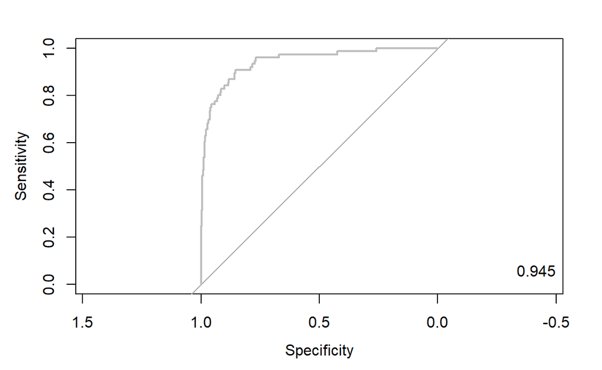

```r
pacman::p_load("pROC")

lda.roc  <- roc(ac, pp, plot = T, col = "gray")         # roc(실제 class, 예측 확률)
auc      <- round(auc(lda.roc), 3)
legend("bottomright", legend = auc, bty = "n")
```

`Caution!` Package `"pROC"`를 통해 출력한 ROC 곡선은 다양한 함수를 이용해서 그래프를 수정할 수 있다.

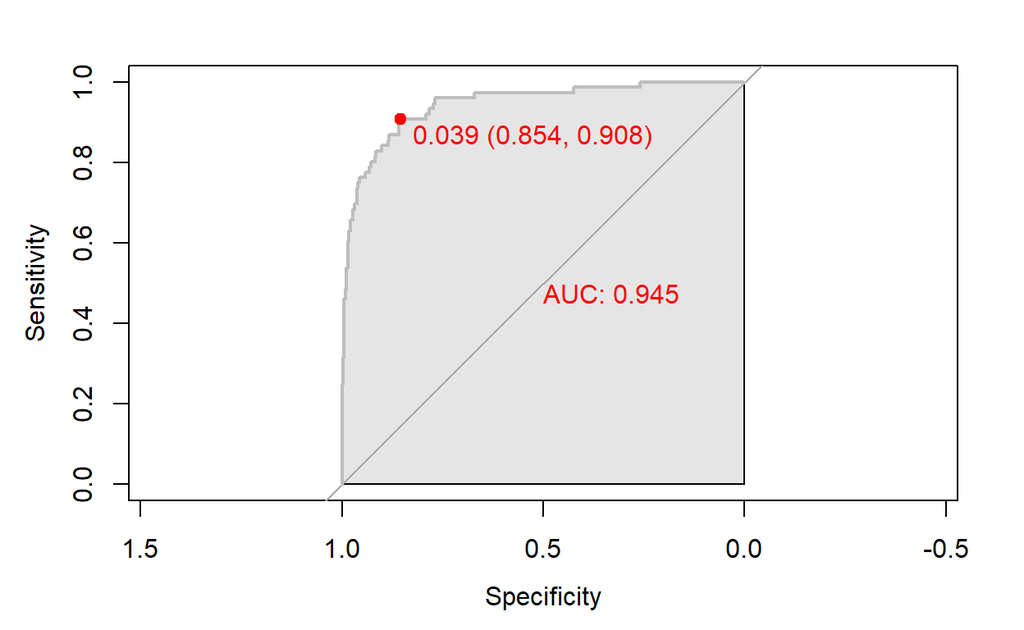

```r
# 함수 plot.roc() 이용
plot.roc(lda.roc,
         col="gray",                                    # Line Color
         print.auc = TRUE,                              # AUC 출력 여부
         print.auc.col = "red",                         # AUC 글씨 색깔
         print.thres = TRUE,                            # Cutoff Value 출력 여부
         print.thres.pch = 19,                          # Cutoff Value를 표시하는 도형 모양
         print.thres.col = "red",                       # Cutoff Value를 표시하는 도형의 색깔
         auc.polygon = TRUE,                            # 곡선 아래 면적에 대한 여부
         auc.polygon.col = "gray90")                    # 곡선 아래 면적의 색깔
```

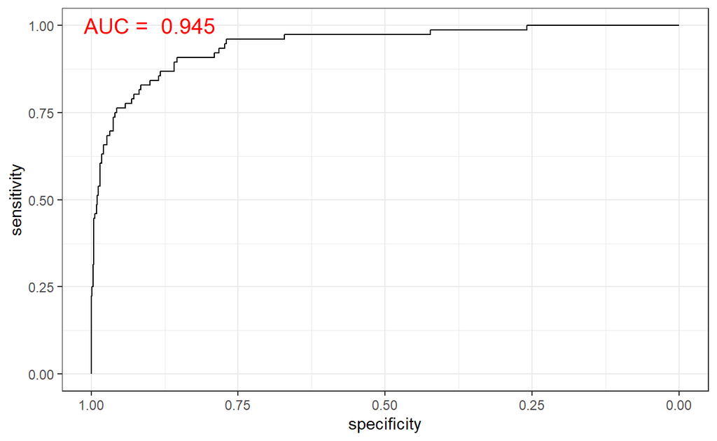

```r
# 함수 ggroc() 이용
ggroc(lda.roc) +
annotate(geom = "text", x = 0.9, y = 1.0,
label = paste("AUC = ", auc),
size = 5,
color="red") +
theme_bw()
```

#### **2) Package “Epi”**

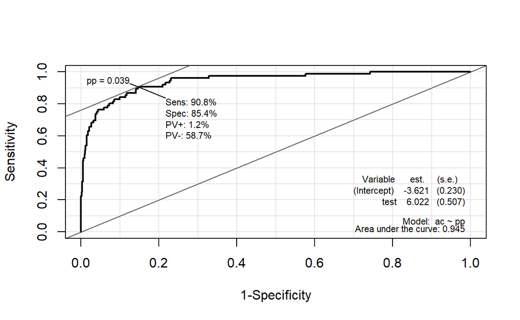

```r
pacman::p_load("Epi")
# install_version("etm", version = "1.1", repos = "http://cran.us.r-project.org")

ROC(pp, ac, plot = "ROC")                                  # ROC(예측 확률, 실제 class)
```

#### **3) Package “ROCR”**

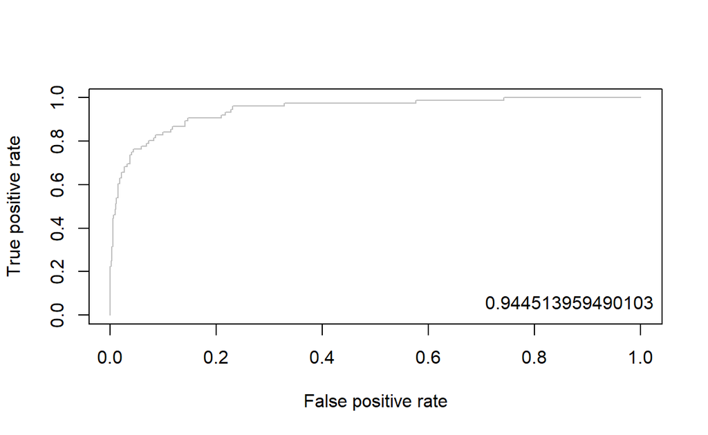

```r
pacman::p_load("ROCR")

lda.pred <- prediction(pp, ac)                             # prediction(예측 확률, 실제 class)

lda.perf <- performance(lda.pred, "tpr", "fpr")            # performance(, "민감도", "1-특이도")
plot(lda.perf, col = "gray")                               # ROC Curve

perf.auc   <- performance(lda.pred, "auc")                 # AUC
auc        <- attributes(perf.auc)$y.values
legend("bottomright", legend = auc, bty = "n")
```

### **7-2-3. 향상 차트**

#### **1) Package “ROCR”**

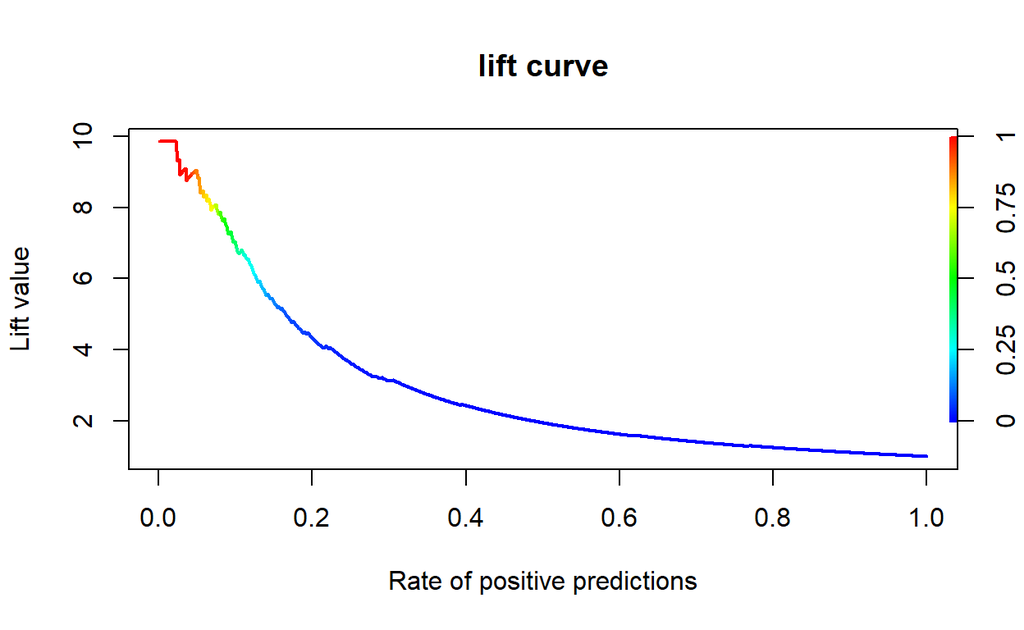

```r
lda.pred <- performance(lda.pred, "lift", "rpp")          # Lift Chart
plot(lda.pred, main = "lift curve",
     colorize = T,                                        # Coloring according to cutoff
     lwd = 2)
```

### **7-2-4. 오분류표**

```r
# 오분류표
lda.ctbl <- table(UB.ted$Personal.Loan,                   # Test Dataset의 실제 class
                  UB.lda.pred$class)                      # 예측 class
lda.ctbl
```

```
       no yes
  no  659  14
  yes  26  50
```

```r
Desc(lda.ctbl,
     digits = 4)
```

```
--------------------------------------------------------------------
lda.ctbl (table)

Summary:
n: 749, rows: 2, columns: 2

Pearson's Chi-squared test (cont. adj):
  X-squared = 346.58, df = 1, p-value < 2.2e-16
Fisher's exact test p-value < 2.2e-16
McNemar's chi-squared = 3.025, df = 1, p-value = 0.08199

                    estimate   lwr.ci   upr.ci'

odds ratio           90.5220  44.4828 184.2112
rel. risk (col1)      2.8623   2.0952   3.9102
rel. risk (col2)      0.0316   0.0184   0.0544


Contingency Coeff.     0.567
Cramer's V             0.688
Kendall Tau-b          0.688


                   no       yes       Sum

no    freq        659        14       673
      perc   87.9840%   1.8692%  89.8531%
      p.row  97.9198%   2.0802%         .
      p.col  96.2044%  21.8750%         .

yes   freq         26        50        76
      perc    3.4713%   6.6756%  10.1469%
      p.row  34.2105%  65.7895%         .
      p.col   3.7956%  78.1250%         .

Sum   freq        685        64       749
      perc   91.4553%   8.5447% 100.0000%
      p.row         .         .         .
      p.col         .         .         .


----------
' 95% conf. level
```

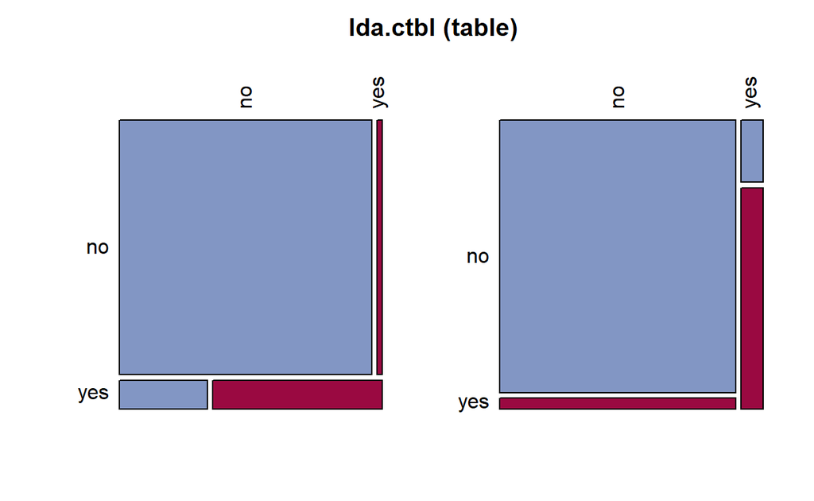

`Result!` `Test Dataset`에 대해서 Target “Personal.Loan”의 “no”에 속하는 673개의 case 중 659개(659/673=97.9%)는 “no”로 제대로 분류되었으나 14개(14/673=2.1%)는 “yes”로 잘못 분류되었다. 또한, Target “Personal.Loan”의 “yes”에 속하는 76개의 case 중 50개(50/76=65.8%)는 “yes”로 제대로 분류되었으나 26개(26/76=34.2%)는 “no”로 잘못 분류되었다. 유도된 선형판별함수에 대한 오분류율은 (14+26)/749=5.3%이며, 정확도는 (659+50)/749=94.7%이다.

# **8. 이차판별분석(QDA)**

## **8-1. 모형 훈련**

`Caution!` Package `"MASS"`에서 제공하는 함수 `qda()`를 통해 이차판별함수를 얻을 수 있다.

```r
UB.qda <- qda(Personal.Loan ~ .,
              # prior = c(1/2, 1/2),            # 사전확률
              data = UB.trd)
UB.qda
```

```
Call:
qda(Personal.Loan ~ ., data = UB.trd)

Prior probabilities of groups:
       no       yes
0.8972016 0.1027984

Group means:
             Age   Experience     Income     ZIP.Code  Family.2
no   0.007050718  0.006493842 -0.1773736 -0.001354389 0.2590707
yes -0.061537099 -0.056676814  1.5480771  0.011820808 0.1722222
     Family.3  Family.4      CCAvg Education.2 Education.3
no  0.1909612 0.2565245 -0.1247715   0.2647995   0.2781668
yes 0.2722222 0.3166667  1.0889781   0.3888889   0.4055556
       Mortgage Securities.Account.1 CD.Account.1  Online.1
no  -0.05226732            0.1094844   0.03437301 0.6034373
yes  0.45617752            0.1444444   0.32222222 0.6611111
    CreditCard.1
no     0.2934437
yes    0.2722222
```

`Caution!` 이차판별분석에서는 판별계수를 출력하지 않는다.

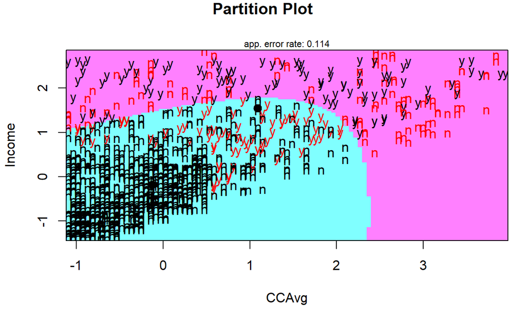

```r
# 두 예측 변수 "Income"와 "CCAvg"에 대해 이차판별분석에 기초한 관측값의 분류 결과
partimat(Personal.Loan ~ Income + CCAvg ,
         data = UB.trd,
         method = "qda")
```

`Result!` 빨간색은 잘못 분류된 case를 의미한다. 선형판별분석에서 살펴본 그림과 달리 곡선형태로 분류 영역이 나뉘어져 있다는 것을 알 수 있다.

## **8-2. 모형 평가**

`Caution!` 모형 평가를 위해 `Test Dataset`에 대한 `예측 class/확률`이 필요하며, 함수 `predict()`를 이용하여 생성한다.

```r
# 예측 class와 예측 확률 생성
UB.qda.pred <- predict(UB.qda,
                       newdata = UB.ted[,-1])           # Test Dataset including Only 예측 변수

UB.qda.pred %>%
  as_tibble
```

```
# A tibble: 749 × 2
   class posterior[,"no"]    [,"yes"]
   <fct>            <dbl>       <dbl>
 1 no               0.999 0.000564
 2 no               1.00  0.0000738
 3 no               1.00  0.000000621
 4 no               1.00  0.000000482
 5 no               1.00  0.0000274
 6 no               1.00  0.00000444
 7 no               1.00  0.000358
 8 no               0.942 0.0584
 9 no               0.991 0.00875
10 no               1.00  0.000201
# ℹ 739 more rows
```

### **8-2-1. ConfusionMatrix**

```r
CM   <- caret::confusionMatrix(UB.qda.pred$class, UB.ted$Personal.Loan,
                               positive = "yes")        # confusionMatrix(예측 class, 실제 class, positive = "관심 class")
CM
```

```
Confusion Matrix and Statistics

          Reference
Prediction  no yes
       no  645  27
       yes  28  49

               Accuracy : 0.9266
                 95% CI : (0.9055, 0.9442)
    No Information Rate : 0.8985
    P-Value [Acc > NIR] : 0.004995

                  Kappa : 0.5996

 Mcnemar's Test P-Value : 1.000000

            Sensitivity : 0.64474
            Specificity : 0.95840
         Pos Pred Value : 0.63636
         Neg Pred Value : 0.95982
             Prevalence : 0.10147
         Detection Rate : 0.06542
   Detection Prevalence : 0.10280
      Balanced Accuracy : 0.80157

       'Positive' Class : yes
```

### **8-2-2. ROC 곡선**

```r
ac  <- UB.ted$Personal.Loan                             # Test Dataset의 실제 class
pp  <- as.numeric(UB.qda.pred$posterior[,2])            # "Personal.Loan = yes"에 대한 예측 확률을 수치형으로 변환
```

#### **1) Package “pROC”**

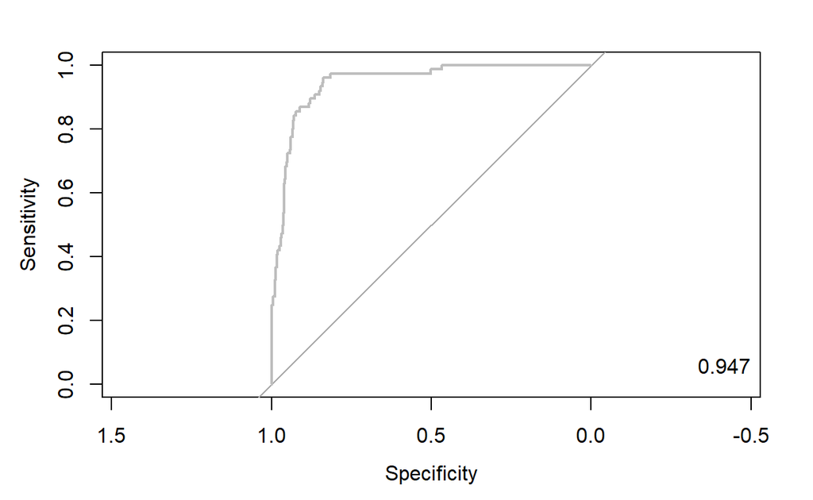

```r
pacman::p_load("pROC")

qda.roc  <- roc(ac, pp, plot = T, col = "gray")         # roc(실제 class, 예측 확률)
auc      <- round(auc(qda.roc), 3)
legend("bottomright", legend = auc, bty = "n")
```

`Caution!` Package `"pROC"`를 통해 출력한 ROC 곡선은 다양한 함수를 이용해서 그래프를 수정할 수 있다.

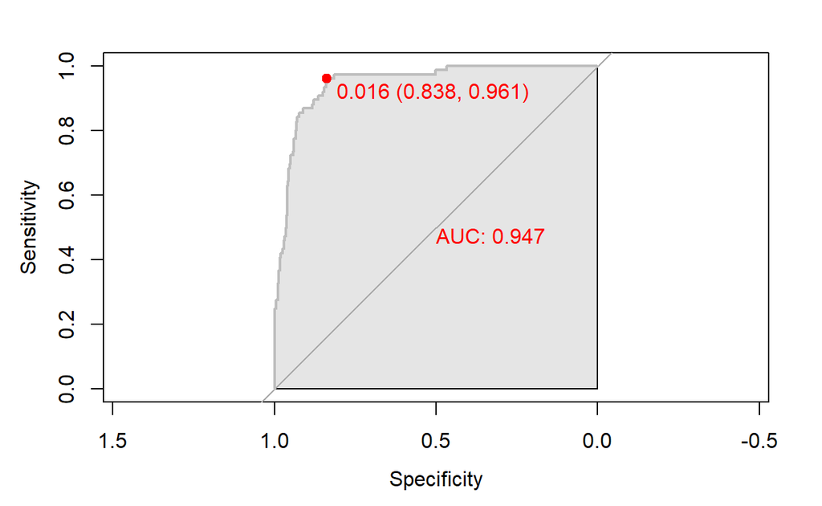

```r
# 함수 plot.roc() 이용
plot.roc(qda.roc,
         col="gray",                                    # Line Color
         print.auc = TRUE,                              # AUC 출력 여부
         print.auc.col = "red",                         # AUC 글씨 색깔
         print.thres = TRUE,                            # Cutoff Value 출력 여부
         print.thres.pch = 19,                          # Cutoff Value를 표시하는 도형 모양
         print.thres.col = "red",                       # Cutoff Value를 표시하는 도형의 색깔
         auc.polygon = TRUE,                            # 곡선 아래 면적에 대한 여부
         auc.polygon.col = "gray90")                    # 곡선 아래 면적의 색깔
```

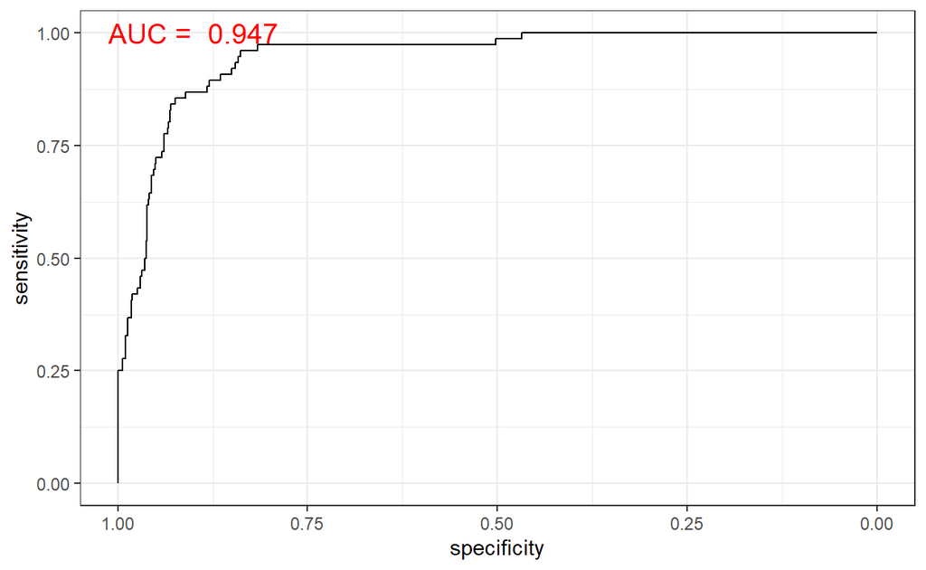

```r
# 함수 ggroc() 이용
ggroc(qda.roc) +
annotate(geom = "text", x = 0.9, y = 1.0,
label = paste("AUC = ", auc),
size = 5,
color="red") +
theme_bw()
```

#### **2) Package “Epi”**

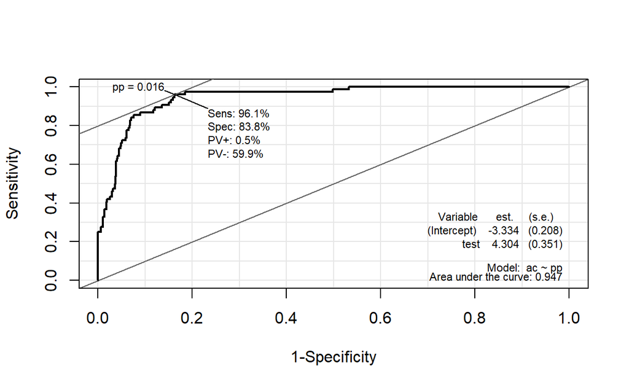

```r
pacman::p_load("Epi")
# install_version("etm", version = "1.1", repos = "http://cran.us.r-project.org")

ROC(pp, ac, plot = "ROC")                                  # ROC(예측 확률, 실제 class)
```

#### **3) Package “ROCR”**

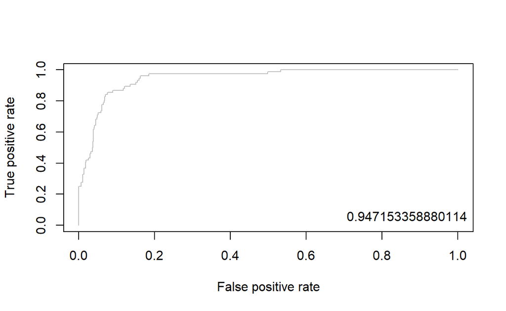

```r
pacman::p_load("ROCR")

qda.pred <- prediction(pp, ac)                             # prediction(예측 확률, 실제 class)

qda.perf <- performance(qda.pred, "tpr", "fpr")            # performance(, "민감도", "1-특이도")
plot(qda.perf, col = "gray")                               # ROC Curve

perf.auc   <- performance(qda.pred, "auc")                 # AUC
auc        <- attributes(perf.auc)$y.values
legend("bottomright", legend = auc, bty = "n")
```

### **8-2-3. 향상 차트**

#### **1) Package “ROCR”**

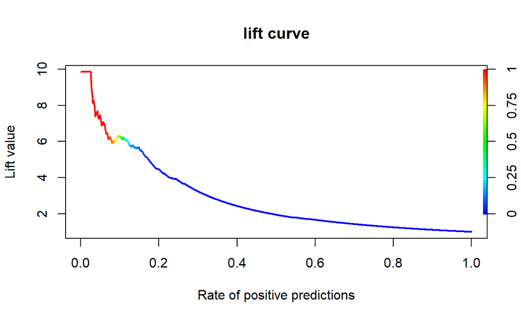

```r
qda.pred <- performance(qda.pred, "lift", "rpp")          # Lift Chart
plot(qda.pred, main = "lift curve",
     colorize = T,                                        # Coloring according to cutoff
     lwd = 2)
```

### **8-2-4. 오분류표**

```r
# 오분류표
qda.ctbl <- table(UB.ted$Personal.Loan,                   # Test Dataset의 실제 class
                  UB.qda.pred$class)                      # 예측 class
qda.ctbl
```

```
       no yes
  no  645  28
  yes  27  49
```

```r
Desc(qda.ctbl,
     digits = 4)
```

```
--------------------------------------------------------------------
qda.ctbl (table)

Summary:
n: 749, rows: 2, columns: 2

Pearson's Chi-squared test (cont. adj):
  X-squared = 262.82, df = 1, p-value < 2.2e-16
Fisher's exact test p-value < 2.2e-16
McNemar's chi-squared = 0, df = 1, p-value = 1

                    estimate  lwr.ci  upr.ci'

odds ratio           41.8056 22.8706 76.4172
rel. risk (col1)      2.6977  1.9920  3.6535
rel. risk (col2)      0.0645  0.0433  0.0962


Contingency Coeff.     0.514
Cramer's V             0.600
Kendall Tau-b          0.600


                   no       yes       Sum

no    freq        645        28       673
      perc   86.1148%   3.7383%  89.8531%
      p.row  95.8395%   4.1605%         .
      p.col  95.9821%  36.3636%         .

yes   freq         27        49        76
      perc    3.6048%   6.5421%  10.1469%
      p.row  35.5263%  64.4737%         .
      p.col   4.0179%  63.6364%         .

Sum   freq        672        77       749
      perc   89.7196%  10.2804% 100.0000%
      p.row         .         .         .
      p.col         .         .         .


----------
' 95% conf. level
```

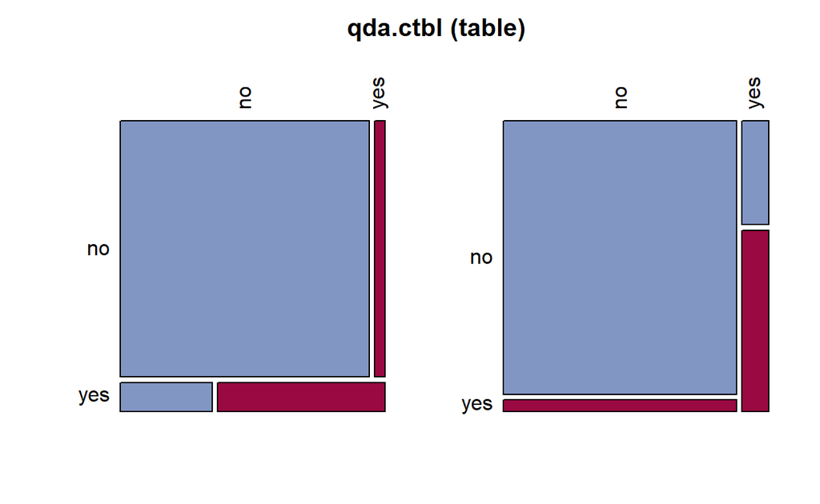

`Result!` `Test Dataset`에 대해서 Target “Personal.Loan”의 “no”에 속하는 673개의 case 중 645개(645/673=95.8%)는 “no”로 제대로 분류되었으나 28개(28/673=4.2%)는 “yes”로 잘못 분류되었다. 또한, Target “Personal.Loan”의 “yes”에 속하는 76개의 case 중 49개(49/76=64.5%)는 “yes”로 제대로 분류되었으나 27개(27/76=35.5%)는 “no”로 잘못 분류되었다. 유도된 이차판별함수에 대한 오분류율은 (28+27)/749=7.3%이며, 정확도는 (645+49)/749=92.7%이다.